# Analysis of longitudinal data

```r
date()
```

```
## [1] "Fri Dec  9 17:31:32 2022"
```

## RATS Data

### Read the data

```r
library(readr); library(dplyr)
RATSL <- readRDS("data/RATSL.rds")

glimpse(RATSL)
```

```
## Rows: 176
## Columns: 5
## $ ID     <fct> 1, 2, 3, 4, 5, 6, 7, 8, 9, 10, 11, 12, 13, 14, 15, 16, 1, 2, 3,…
## $ Group  <fct> 1, 1, 1, 1, 1, 1, 1, 1, 2, 2, 2, 2, 3, 3, 3, 3, 1, 1, 1, 1, 1, …
## $ WD     <chr> "WD1", "WD1", "WD1", "WD1", "WD1", "WD1", "WD1", "WD1", "WD1", …
## $ Weight <int> 240, 225, 245, 260, 255, 260, 275, 245, 410, 405, 445, 555, 470…
## $ Time   <int> 1, 1, 1, 1, 1, 1, 1, 1, 1, 1, 1, 1, 1, 1, 1, 1, 8, 8, 8, 8, 8, …
```

As I have already saved the data in RDS format, it wasn’t necessary to run the factoring. So the categorical variables already saved as factors.

This data set (RATS) includes data from a nutrition study: rats were divided into 3 groups where each groups had different diets. The weight of the rats was monitored during the 9-week period.

The data descriptions were given in the R script, so I did not include it here again.

### Graphical Overview

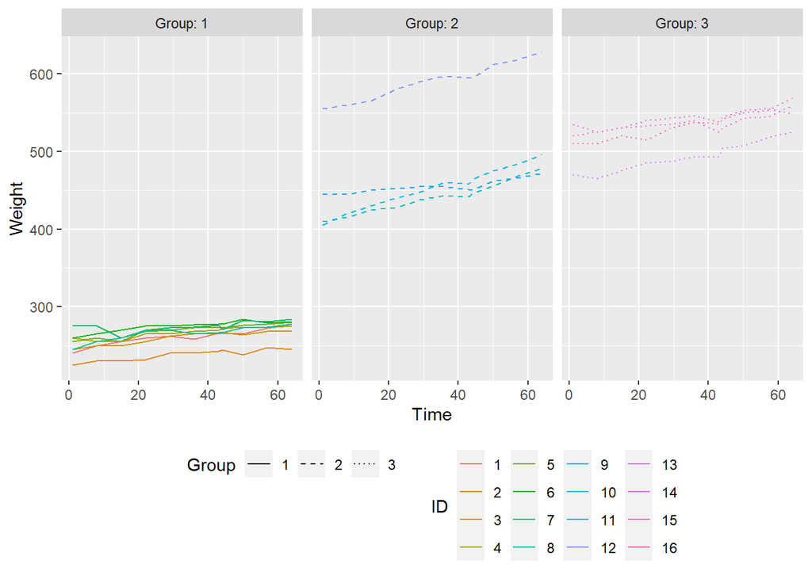

```r
library(dplyr)
library(tidyr)
library(ggplot2)
library(rstatix)
# Draw the plot
ggplot(RATSL, aes(x = Time , y = Weight, linetype = Group, color= ID)) +
  geom_line() +
  scale_linetype_manual(values = rep(1:10, times=4)) +
  facet_grid(. ~ Group, labeller = label_both) +
  theme(legend.position = "bottom") +
  scale_y_continuous(limits = c(min(RATSL$Weight), max(RATSL$Weight)))
```

In all three groups, the weight has increased over the time. As the average initial weight is very lower in group 1, compared to the groups 2 and group 3, therefore the end weight is also very low compared to the other two groups. Overall the third group has the heaviest rats. But in the second group, there is one rat which is the heaviest out of all the rats in all the groups. It looks like an outlier. All the other rats in all the groups seems to have a similar weight at the begining and at the end of the study.

### Standardized Overview

```r
RATSL <- RATSL %>%
  group_by(Time) %>%
  mutate(stdweight = (Weight - mean(Weight))/sd(Weight)) %>%
  ungroup()

glimpse(RATSL)
```

```
## Rows: 176
## Columns: 6
## $ ID        <fct> 1, 2, 3, 4, 5, 6, 7, 8, 9, 10, 11, 12, 13, 14, 15, 16, 1, 2,…
## $ Group     <fct> 1, 1, 1, 1, 1, 1, 1, 1, 2, 2, 2, 2, 3, 3, 3, 3, 1, 1, 1, 1, …
## $ WD        <chr> "WD1", "WD1", "WD1", "WD1", "WD1", "WD1", "WD1", "WD1", "WD1…
## $ Weight    <int> 240, 225, 245, 260, 255, 260, 275, 245, 410, 405, 445, 555, …
## $ Time      <int> 1, 1, 1, 1, 1, 1, 1, 1, 1, 1, 1, 1, 1, 1, 1, 1, 8, 8, 8, 8, …
## $ stdweight <dbl> -1.0011429, -1.1203857, -0.9613953, -0.8421525, -0.8819001, …
```

```r
str(RATSL)
```

```
## tibble [176 × 6] (S3: tbl_df/tbl/data.frame)
##  $ ID       : Factor w/ 16 levels "1","2","3","4",..: 1 2 3 4 5 6 7 8 9 10 ...
##  $ Group    : Factor w/ 3 levels "1","2","3": 1 1 1 1 1 1 1 1 2 2 ...
##  $ WD       : chr [1:176] "WD1" "WD1" "WD1" "WD1" ...
##  $ Weight   : int [1:176] 240 225 245 260 255 260 275 245 410 405 ...
##  $ Time     : int [1:176] 1 1 1 1 1 1 1 1 1 1 ...
##  $ stdweight: num [1:176] -1.001 -1.12 -0.961 -0.842 -0.882 ...
```

```r
summary(RATSL)
```

```
##        ID      Group       WD                Weight           Time
##  1      : 11   1:88   Length:176         Min.   :225.0   Min.   : 1.00
##  2      : 11   2:44   Class :character   1st Qu.:267.0   1st Qu.:15.00
##  3      : 11   3:44   Mode  :character   Median :344.5   Median :36.00
##  4      : 11                             Mean   :384.5   Mean   :33.55
##  5      : 11                             3rd Qu.:511.2   3rd Qu.:50.00
##  6      : 11                             Max.   :628.0   Max.   :64.00
##  (Other):110
##    stdweight
##  Min.   :-1.1618
##  1st Qu.:-0.9084
##  Median :-0.2062
##  Mean   : 0.0000
##  3rd Qu.: 0.9235
##  Max.   : 1.6330
##
```

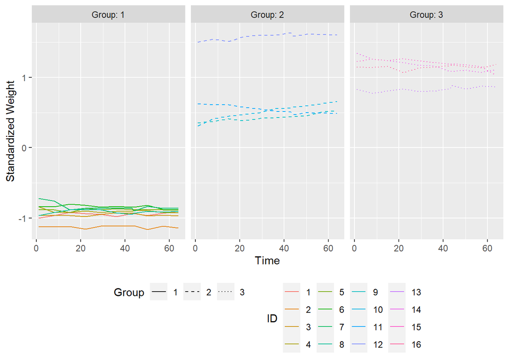

```r
# Draw the new plot with standardized weight
ggplot(RATSL, aes(x = Time , y = stdweight, linetype = Group, color= ID)) +
  geom_line() +
  scale_linetype_manual(values = rep(1:10, times=4)) +
  facet_grid(. ~ Group, labeller = label_both) +
  theme(legend.position = "bottom") +
  scale_y_continuous(name = "Standardized Weight", limits = c(min(RATSL$stdweight), max(RATSL$stdweight)))
```

After standardizing the weight, we can see that there is a slight decrease in the third group while the second group shows a slight increase in weight. However the first group shows a flat line: no increase nor decrease in weight.

### Summary Graphs

```r
# Number of subjects (per group):
n <- 8

# Summary data with mean and standard error of RATSA by Group and Time
RATSS <- RATSL %>%
  group_by(Group, Time) %>%
  summarise( mean = mean(Weight), se = sd(Weight) ) %>%
  ungroup()
# Glimpse the data
glimpse(RATSS)
```

```
## Rows: 33
## Columns: 4
## $ Group <fct> 1, 1, 1, 1, 1, 1, 1, 1, 1, 1, 1, 2, 2, 2, 2, 2, 2, 2, 2, 2, 2, 2…
## $ Time  <int> 1, 8, 15, 22, 29, 36, 43, 44, 50, 57, 64, 1, 8, 15, 22, 29, 36, …
## $ mean  <dbl> 250.625, 255.000, 254.375, 261.875, 264.625, 265.000, 267.375, 2…
## $ se    <dbl> 15.22158, 13.09307, 11.47591, 13.60081, 11.05748, 11.78377, 10.9…
```

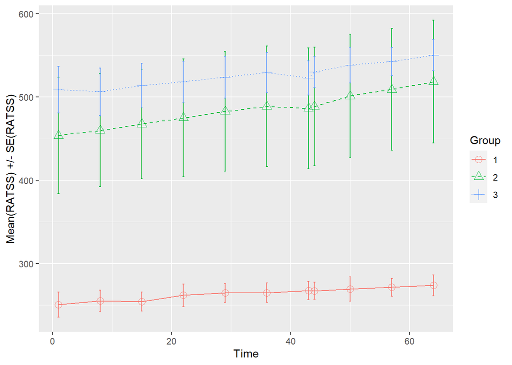

```r
# Plot the mean profiles
ggplot(RATSS, aes(x = Time, y = mean, linetype = Group, shape=Group, color=Group)) +
  geom_line() +
  scale_linetype_manual(values = c(1,2,3)) +
  geom_point(size=3) +
  scale_shape_manual(values = c(1,2,3)) +
  geom_errorbar(aes(ymin=mean-se, ymax=mean+se, linetype="1"), width=0.3) +
  theme(legend.position = "right") +
  scale_y_continuous(name = "Mean(RATSS) +/- SE(RATSS)")
```

The weight of the rats in Group 1 is the lowest on average, while rats in the Group 3 shows the highest weight on average. Moreover, from the error bars we can see that the rats in Group 2 and Group 3 shows more variability throughout the time compared to the rats in Group 1.

```r
# Create a summary data by Group and ID with mean as the summary variable (ignoring baseline Time 1)
RATSL8S <- RATSL %>%
  filter(Time > 1) %>%
  group_by(Group, ID) %>%
  summarise( mean=mean(Weight) ) %>%
  ungroup()
# Glimpse the data
glimpse(RATSL8S)
```

```
## Rows: 16
## Columns: 3
## $ Group <fct> 1, 1, 1, 1, 1, 1, 1, 1, 2, 2, 2, 2, 3, 3, 3, 3
## $ ID    <fct> 1, 2, 3, 4, 5, 6, 7, 8, 9, 10, 11, 12, 13, 14, 15, 16
## $ mean  <dbl> 263.2, 238.9, 261.7, 267.2, 270.9, 276.2, 274.6, 267.5, 443.9, 4…
```

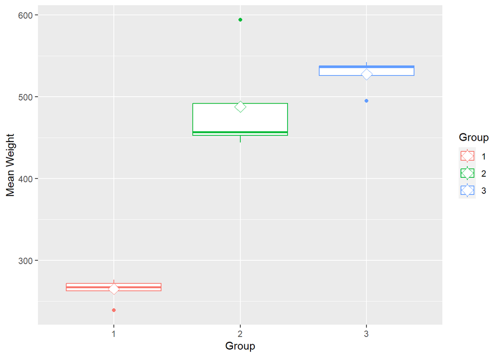

```r
# Draw a boxplot of the mean versus weight
ggplot(RATSL8S, aes(x = Group, y = mean, group=Group, color=Group)) +
  geom_boxplot() +
  stat_summary(fun = "mean", geom = "point", shape=23, size=4, fill = "white") +
  scale_y_continuous(name = "Mean Weight")
```

As we already observed from previous plots, from this plot also we can see that the the average weight of Group 3 has the highest average weight.

Furthermore, we can see some outliers in all three groups. Thus, the plot was recreated after removing the outliers.

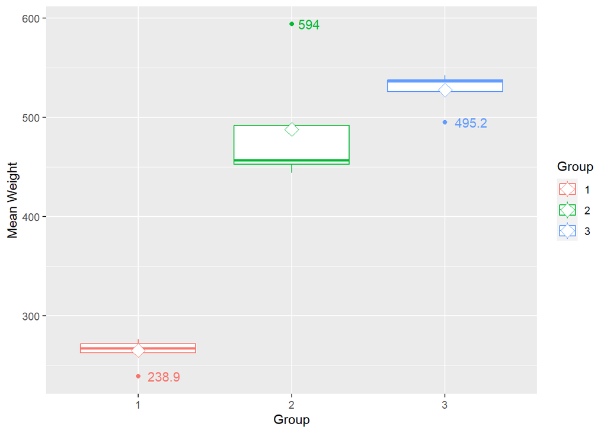

```r
# Finding the outliers
is_outlier <- function(x) {
  return(x < quantile(x, 0.25) - 1.5 * IQR(x) | x > quantile(x, 0.75) + 1.5 * IQR(x))
}

# Re-plot with Defined outliers
RATSL8S %>%
  group_by(Group) %>%
  mutate(outlier = ifelse(is_outlier(mean), mean, as.numeric(NA))) %>%
  ggplot(., aes(x = Group, y = mean, group=Group, color=Group)) +
    geom_boxplot() +
    geom_text(aes(label = outlier), na.rm = TRUE, hjust = -0.3) +
    stat_summary(fun = "mean", geom = "point", shape=23, size=4, fill = "white") +
    scale_y_continuous(name = "Mean Weight")
```

Now it is easier to remove the outliers.

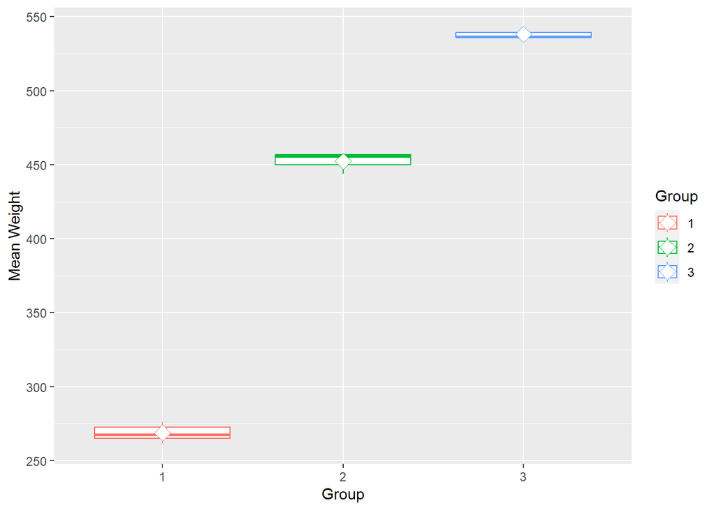

```r
RATSL8SF <- filter(RATSL8S,
                    mean > 250 & Group == '1' |
                    mean < 550 & Group == '2' |
                    mean > 500 & Group == '3')

ggplot(RATSL8SF, aes(x = Group, y = mean, group=Group, color=Group)) +
  geom_boxplot() +
  stat_summary(fun = "mean", geom = "point", shape=23, size=4, fill = "white") +
  scale_y_continuous(name = "Mean Weight")
```

### Statistical Tests

```r
# T Test
for(i in list(c('1', '2'), c('2', '3'), c('1', '3'))){
    print(t.test(mean ~ Group,
    data = filter(RATSL8SF, Group == i[1] | Group == i[2]),
    var.equal = TRUE))
}
```

```
##
##  Two Sample t-test
##
## data:  mean by Group
## t = -44.305, df = 8, p-value = 7.434e-11
## alternative hypothesis: true difference in means between group 1 and group 2 is not equal to 0
## 95 percent confidence interval:
##  -193.2012 -174.0845
## sample estimates:
## mean in group 1 mean in group 2
##        268.7571        452.4000
##
##
##  Two Sample t-test
##
## data:  mean by Group
## t = -18.235, df = 4, p-value = 5.32e-05
## alternative hypothesis: true difference in means between group 2 and group 3 is not equal to 0
## 95 percent confidence interval:
##  -98.94088 -72.79246
## sample estimates:
## mean in group 2 mean in group 3
##        452.4000        538.2667
##
##
##  Two Sample t-test
##
## data:  mean by Group
## t = -77.715, df = 8, p-value = 8.377e-13
## alternative hypothesis: true difference in means between group 1 and group 3 is not equal to 0
## 95 percent confidence interval:
##  -277.5065 -261.5125
## sample estimates:
## mean in group 1 mean in group 3
##        268.7571        538.2667
```

As there are three groups, three T tests were conducted by taking two at a time. All the tests are significant (p<0.05).

```r
# ANOVA Test

# Fit the linear model with the mean as the response
fit <- lm(mean ~ Group, data = RATSL8S)
summary(fit)
```

```
##
## Call:
## lm(formula = mean ~ Group, data = RATSL8S)
##
## Residuals:
##     Min      1Q  Median      3Q     Max
## -43.900 -27.169   2.325   9.069 106.200
##
## Coefficients:
##             Estimate Std. Error t value Pr(>|t|)
## (Intercept)   265.02      12.98  20.419 2.92e-11 ***
## Group2        222.77      22.48   9.909 2.00e-07 ***
## Group3        262.48      22.48  11.675 2.90e-08 ***
## ---
## Signif. codes:  0 '***' 0.001 '**' 0.01 '*' 0.05 '.' 0.1 ' ' 1
##
## Residual standard error: 36.71 on 13 degrees of freedom
## Multiple R-squared:  0.9316, Adjusted R-squared:  0.9211
## F-statistic: 88.52 on 2 and 13 DF,  p-value: 2.679e-08
```

```r
# Compute the analysis of variance table for the fitted model with anova()
anova(fit)
```

```
## Analysis of Variance Table
##
## Response: mean
##           Df Sum Sq Mean Sq F value    Pr(>F)
## Group      2 238620  119310  88.525 2.679e-08 ***
## Residuals 13  17521    1348
## ---
## Signif. codes:  0 '***' 0.001 '**' 0.01 '*' 0.05 '.' 0.1 ' ' 1
```

At first, I ran this without considering the baseline. All the groups have significant relationships with the mean weight. This model predicts the 92.11% of the variance of the dependenat variable. Through the Anova test: as it is significant we can conclude there is a significant difference in the groups of rats to their weight.

```r
# read the RATS data to get baseline values
RATS <- read.table("https://raw.githubusercontent.com/KimmoVehkalahti/MABS/master/Examples/data/rats.txt", header = TRUE, sep = '\t')

# add the baseline from the original data as a new variable to the summary data
RATSL8S2 <- RATSL8S %>%
  mutate(baseline = RATS$WD1) %>%
  filter(mean < 590) # to get the similar observations

# fit the linear model with the mean as the response
fit2 <- lm(mean ~ baseline + Group, data = RATSL8S2)
summary(fit2)
```

```
##
## Call:
## lm(formula = mean ~ baseline + Group, data = RATSL8S2)
##
## Residuals:
##      Min       1Q   Median       3Q      Max
## -11.2818  -5.4247  -0.0667   5.7389  13.7887
##
## Coefficients:
##             Estimate Std. Error t value Pr(>|t|)
## (Intercept) 119.8515    31.5069   3.804 0.002923 **
## baseline      0.5792     0.1251   4.630 0.000728 ***
## Group2       89.2652    22.0021   4.057 0.001892 **
## Group3      112.9571    32.7344   3.451 0.005421 **
## ---
## Signif. codes:  0 '***' 0.001 '**' 0.01 '*' 0.05 '.' 0.1 ' ' 1
##
## Residual standard error: 8.749 on 11 degrees of freedom
## Multiple R-squared:  0.996,  Adjusted R-squared:  0.9949
## F-statistic: 911.4 on 3 and 11 DF,  p-value: 1.842e-13
```

As we already know from previous tests and plots, in the base model, the mean weight differs significantly between groups. The model explains 99.49% of the variation in mean weight of the rats. Thus the baseline weight is a statistically significant variable to the model. It explains more of the variation than just with the treatment.

## BPRS Data

### Read the data

```r
BPRSL <- readRDS("data/BPRSL.rds")

glimpse(BPRSL)
```

```
## Rows: 360
## Columns: 4
## $ treatment <fct> 1, 1, 1, 1, 1, 1, 1, 1, 1, 1, 1, 1, 1, 1, 1, 1, 1, 1, 1, 1, …
## $ subject   <fct> 1, 2, 3, 4, 5, 6, 7, 8, 9, 10, 11, 12, 13, 14, 15, 16, 17, 1…
## $ weeks     <int> 0, 0, 0, 0, 0, 0, 0, 0, 0, 0, 0, 0, 0, 0, 0, 0, 0, 0, 0, 0, …
## $ bprs      <int> 42, 58, 54, 55, 72, 48, 71, 30, 41, 57, 30, 55, 36, 38, 66, …
```

Similar to the RATS data, BPRS data also saved in the RDS format. Thus, there were no need of converting to categorical form.

The BPRS: Brief Psychiatric Rating Scale data includes 40 males which were randomly assigned to one of two treatment groups. Each participant was rated on the BPRS measured before and during the treatment for 8 weeks. The BPRS assesses the level of 18 symptom constructs. The scale is used to evaluate patients suspected of having schizophrenia.

The data descriptions were given in the R script, so I did not include it here again.

### Graphocal Overview

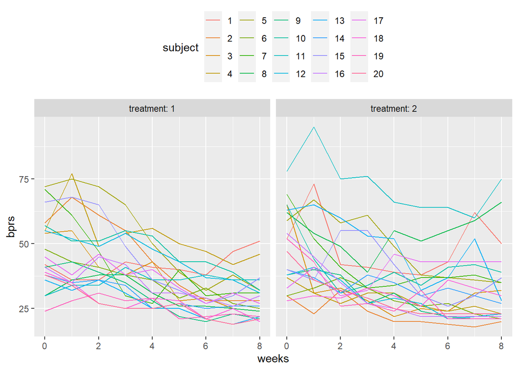

```r
library(ggplot2)
ggplot(BPRSL, aes(x = weeks, y = bprs, group = subject)) +
  geom_line(aes(col = subject)) +
  theme(legend.position = "top") +
  facet_grid(. ~ treatment, labeller = label_both)
```

In both treatment groups, there cannot be seen a huge difference. Over the time, the BPRS has been decreased in both scenarios.

### The Random Intercept Model

```r
# create a regression model
BPRS_reg <- lm(bprs ~ weeks + treatment, BPRSL)

# print out a summary of the model
summary(BPRS_reg)
```

```
##
## Call:
## lm(formula = bprs ~ weeks + treatment, data = BPRSL)
##
## Residuals:
##     Min      1Q  Median      3Q     Max
## -22.454  -8.965  -3.196   7.002  50.244
##
## Coefficients:
##             Estimate Std. Error t value Pr(>|t|)
## (Intercept)  46.4539     1.3670  33.982   <2e-16 ***
## weeks        -2.2704     0.2524  -8.995   <2e-16 ***
## treatment2    0.5722     1.3034   0.439    0.661
## ---
## Signif. codes:  0 '***' 0.001 '**' 0.01 '*' 0.05 '.' 0.1 ' ' 1
##
## Residual standard error: 12.37 on 357 degrees of freedom
## Multiple R-squared:  0.1851, Adjusted R-squared:  0.1806
## F-statistic: 40.55 on 2 and 357 DF,  p-value: < 2.2e-16
```

First, I fitted a linear regression model which assumes independence of the repeated measures of weight. Based on this model, weeks are statistically significant and treatment group is not. The model explaines only 18.06% of the total variance of the bprs, which is quite low.

Then I fitted a Random Intercept Model, which allows within-subject dependencies.

```r
library(lme4)
# Create a random intercept model
BPRS_ref <- lmer(bprs ~ weeks + treatment + (1 | subject), data = BPRSL, REML = FALSE)

# Print the summary of the model
summary(BPRS_ref)
```

```
## Linear mixed model fit by maximum likelihood  ['lmerMod']
## Formula: bprs ~ weeks + treatment + (1 | subject)
##    Data: BPRSL
##
##      AIC      BIC   logLik deviance df.resid
##   2748.7   2768.1  -1369.4   2738.7      355
##
## Scaled residuals:
##     Min      1Q  Median      3Q     Max
## -3.0481 -0.6749 -0.1361  0.4813  3.4855
##
## Random effects:
##  Groups   Name        Variance Std.Dev.
##  subject  (Intercept)  47.41    6.885
##  Residual             104.21   10.208
## Number of obs: 360, groups:  subject, 20
##
## Fixed effects:
##             Estimate Std. Error t value
## (Intercept)  46.4539     1.9090  24.334
## weeks        -2.2704     0.2084 -10.896
## treatment2    0.5722     1.0761   0.532
##
## Correlation of Fixed Effects:
##            (Intr) weeks
## weeks      -0.437
## treatment2 -0.282  0.000
```

Based on the results of the fitted random intercept model, the estimated variance of the subject random effects is 47.41: there is no high variation between the intercepts of the regression fits and the individuals. Furthermore, the estimated standard error of week is only a little lower compared to the previous model which assumed the independency between variables. Thus, it seems that there is no much difference between the models.

### Random Intercept and Random Slope Model

```r
# Create a random intercept model and random slope model
BPRS_ref1 <- lmer(bprs ~ weeks + treatment + (weeks | subject), data = BPRSL, REML = FALSE)

# print a summary of the model
summary(BPRS_ref1)
```

```
## Linear mixed model fit by maximum likelihood  ['lmerMod']
## Formula: bprs ~ weeks + treatment + (weeks | subject)
##    Data: BPRSL
##
##      AIC      BIC   logLik deviance df.resid
##   2745.4   2772.6  -1365.7   2731.4      353
##
## Scaled residuals:
##     Min      1Q  Median      3Q     Max
## -2.8919 -0.6194 -0.0691  0.5531  3.7976
##
## Random effects:
##  Groups   Name        Variance Std.Dev. Corr
##  subject  (Intercept) 64.8222  8.0512
##           weeks        0.9609  0.9802   -0.51
##  Residual             97.4305  9.8707
## Number of obs: 360, groups:  subject, 20
##
## Fixed effects:
##             Estimate Std. Error t value
## (Intercept)  46.4539     2.1052  22.066
## weeks        -2.2704     0.2977  -7.626
## treatment2    0.5722     1.0405   0.550
##
## Correlation of Fixed Effects:
##            (Intr) weeks
## weeks      -0.582
## treatment2 -0.247  0.000
```

I fitted the Random Intercept and Random Slope Model, which allows linear regression fits for each individual to differ in intercept and also in slope.

Compared to the random intercept model, here the estimated variance of the subject is considerably higher, indicating variation between the intercepts of the regression fits of the individuals. Even though the standard error is higher than the previous model, it does not seem that the difference between the models is really large.

```r
# Perform ANOVA tests on the two models
anova(BPRS_ref1, BPRS_ref)
```

```
## Data: BPRSL
## Models:
## BPRS_ref: bprs ~ weeks + treatment + (1 | subject)
## BPRS_ref1: bprs ~ weeks + treatment + (weeks | subject)
##           npar    AIC    BIC  logLik deviance  Chisq Df Pr(>Chisq)
## BPRS_ref     5 2748.7 2768.1 -1369.4   2738.7
## BPRS_ref1    7 2745.4 2772.6 -1365.7   2731.4 7.2721  2    0.02636 *
## ---
## Signif. codes:  0 '***' 0.001 '**' 0.01 '*' 0.05 '.' 0.1 ' ' 1
```

### Random Intercept and Random Slope Model with interaction

```r
# Create a random intercept and random slope model with the interaction
BPRS_ref2 <- lmer(bprs ~ weeks + treatment + weeks * treatment + (weeks | subject), data = BPRSL, REML = FALSE)

# print a summary of the model
summary(BPRS_ref2)
```

```
## Linear mixed model fit by maximum likelihood  ['lmerMod']
## Formula: bprs ~ weeks + treatment + weeks * treatment + (weeks | subject)
##    Data: BPRSL
##
##      AIC      BIC   logLik deviance df.resid
##   2744.3   2775.4  -1364.1   2728.3      352
##
## Scaled residuals:
##     Min      1Q  Median      3Q     Max
## -3.0512 -0.6271 -0.0768  0.5288  3.9260
##
## Random effects:
##  Groups   Name        Variance Std.Dev. Corr
##  subject  (Intercept) 64.9964  8.0620
##           weeks        0.9687  0.9842   -0.51
##  Residual             96.4707  9.8220
## Number of obs: 360, groups:  subject, 20
##
## Fixed effects:
##                  Estimate Std. Error t value
## (Intercept)       47.8856     2.2521  21.262
## weeks             -2.6283     0.3589  -7.323
## treatment2        -2.2911     1.9090  -1.200
## weeks:treatment2   0.7158     0.4010   1.785
##
## Correlation of Fixed Effects:
##             (Intr) weeks  trtmn2
## weeks       -0.650
## treatment2  -0.424  0.469
## wks:trtmnt2  0.356 -0.559 -0.840
```

```r
# perform an ANOVA test on the two models
anova(BPRS_ref2, BPRS_ref1)
```

```
## Data: BPRSL
## Models:
## BPRS_ref1: bprs ~ weeks + treatment + (weeks | subject)
## BPRS_ref2: bprs ~ weeks + treatment + weeks * treatment + (weeks | subject)
##           npar    AIC    BIC  logLik deviance  Chisq Df Pr(>Chisq)
## BPRS_ref1    7 2745.4 2772.6 -1365.7   2731.4
## BPRS_ref2    8 2744.3 2775.4 -1364.1   2728.3 3.1712  1    0.07495 .
## ---
## Signif. codes:  0 '***' 0.001 '**' 0.01 '*' 0.05 '.' 0.1 ' ' 1
```

Either the random intercept model and or the slope model is better than the linear regression model in this data (BPRS), but it does not seem to consider whether the model includes interaction or not.

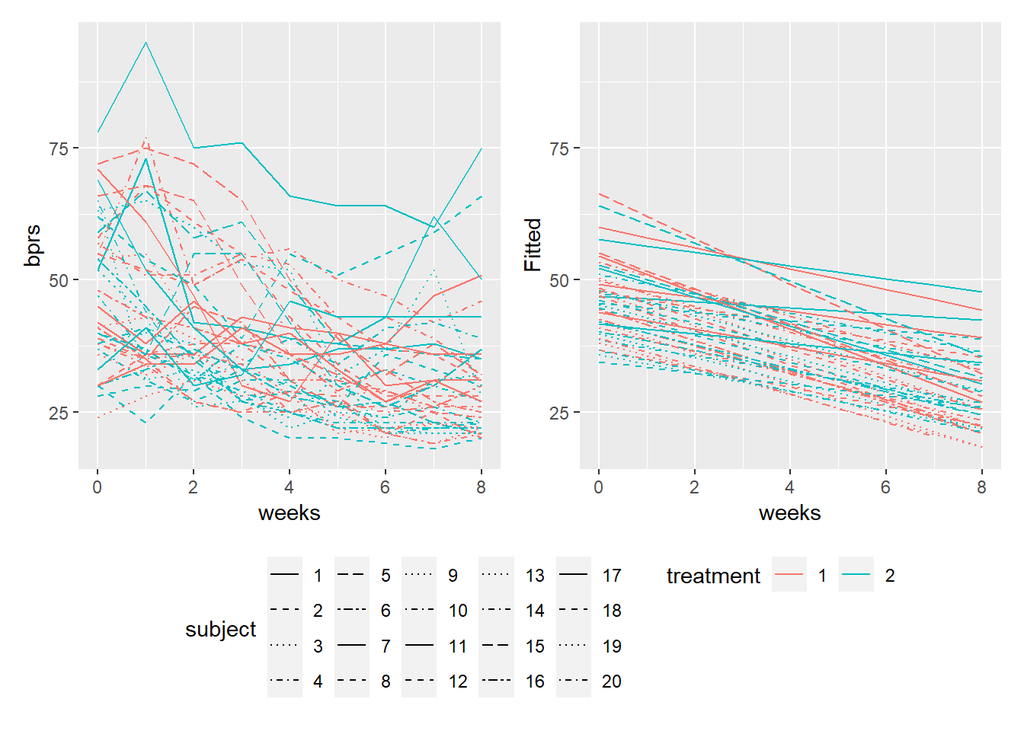

```r
library(patchwork)
BPRSL <- BPRSL %>% mutate(Fitted = fitted(BPRS_ref2))

# draw the plot of RATSL with the observed Weight values
a <- ggplot(BPRSL, aes(x = weeks, y = bprs, color = treatment)) +
  geom_line(aes(linetype = subject)) +
  scale_linetype_manual(values = rep(1:10, times=4)) +
  scale_y_continuous(limits = c(min(BPRSL$bprs), max(BPRSL$bprs)))

# draw the plot of RATSL with the Fitted values of weight
b <- ggplot(BPRSL, aes(x = weeks, y = Fitted, color = treatment)) +
  geom_line(aes(linetype = subject)) +
  scale_linetype_manual(values = rep(1:10, times=4)) +
  scale_y_continuous(limits = c(min(BPRSL$bprs), max(BPRSL$bprs)))

(a + b & theme(legend.position = "bottom")) + plot_layout(guides = "collect")
```

From the above plot we can see how well the random intercept and slope model with interaction fits. The treatment is visualized by colors and the subject is visualized by line styles. Even though it is hard to tell a lot from this, it is clear that the bprs is decreasing regardless of treatment.